# Onefootball x Adidas

A brand user survey, April 2020

Konstantin Escher & Moritz Bräuning

2020-05-05

[figure not shown]

[figure not shown]

# Introduction

This project was executed by the User Research Team in collaboration with *Cintia Oliveira* and *Paul Mehling* from the Sales Department. For our client *Adidas* we ran a user survey in four markets as part of a contractial agreement. This document contains a summary of the execution and data analysis.

# Methodology

This survey was run at two moments of time: **t0** before the Adidas campaign and **t1** after the campaign. Both surveys and questions incl. their order are identical. t0 target a random sample of Onefootball users from Germany, the UK, Spain and France. t1 targeted only those Onefootball users who previously participated in t0. In the following we are looking at the sample size per measurement time and market.

| market | time | sample size |
| --- | --- | --- |
| DE | post | 26 |
| DE | pre | 117 |
| ES | post | 5 |
| ES | pre | 27 |
| FR | post | 3 |
| FR | pre | 40 |
| UK | post | 10 |
| UK | pre | 49 |

# User Demographics

## Age distribution

As a first step, we are looking at the age and gender distribution of the participants. For this, we combine all Onefootball users who participated in either t0 or both surveys. We observe that 39% of participants are younger than 25 years. Yet, we also observe a significant share of participants older than 34 years.

| agegroup | share | absolute |
| --- | --- | --- |
| 14 to 18 | 26% | 72 |
| 19 to 24 | 13% | 36 |
| 25 to 29 | 8% | 21 |
| 30 to 34 | 7% | 20 |
| 35 to 44 | 12% | 32 |
| 45 or older | 35% | 96 |

## Gender distribution

As expected, we observe a major share of participants being male, representing the overall Onefootball audience.

**Methodology:** Those % missing to 100% are those who refused to answer the question.

| gender | share | absolute |
| --- | --- | --- |
| Female | 15% | 42 |
| Male | 82% | 227 |

# Brand Recognition

We wanted to understand how well known *adidas* is among our Onefootball users compared to other sports manufactoring brands. The survey found that *adidas* is one of the most known and recoginzed sports brands (82% at *pre*) in our sample. We can see an uplift of 14% in brand recognition after the campaign was run on Onefootball (*post*). Yet, we observe an overall increase in brand recognition for all brands in the pool.

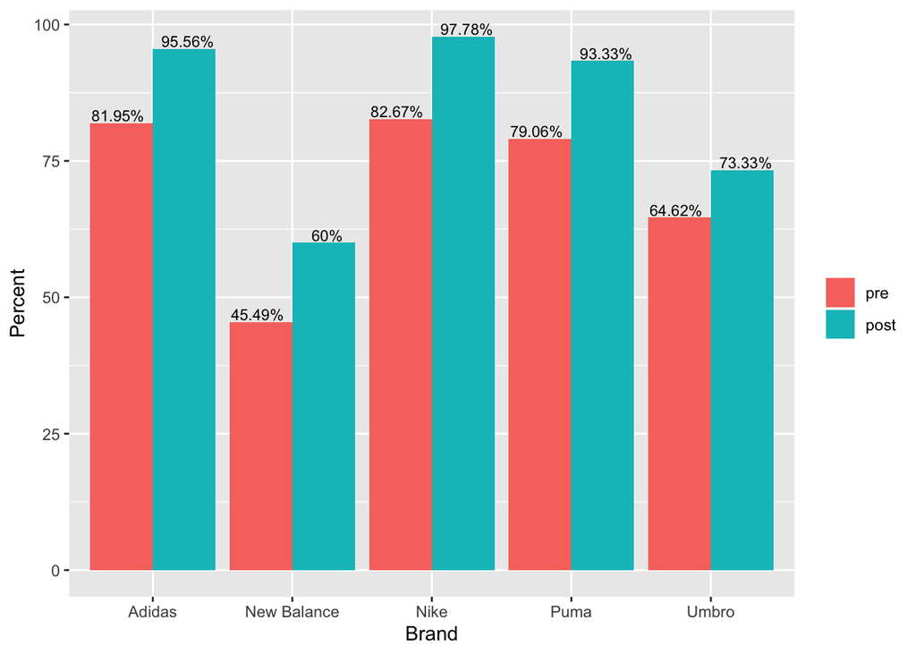

# Ad recall

We wanted to understand if our users remember *adidas* advertising, both overall and specificly on Onefootball.

## overall

We can observe that there is already a high recognition for Adidas (78%) and Nike (79%) in *pre* period. But while for Nike the ad recall decreases in the *post* measure, we find an uplift to 82% for adidas.

| time | Nike | Adidas | Puma | New Balance | Umbro |
| --- | --- | --- | --- | --- | --- |
| pre | 78.97 | 78.11 | 47.64 | 15.88 | 9.01 |
| post | 77.27 | 81.82 | 47.73 | 11.36 | 18.18 |

## on Onefootball

After running the campaign on Onefootball, we find a significant uplift in ad recall on Onefootball (+10%). These results can be considered a great success for all parties.

| time | Nike | Adidas | Puma | Umbro |
| --- | --- | --- | --- | --- |
| pre | 51.63 | 51.10 | 28.83 | 19.05 |
| post | 58.82 | 61.11 | 19.05 | 25.00 |

# Player Brand Association

We asked our users which players they associate with a certain set of brand (adidas, Puma, Nike) and looked for changes in the level of association. For analytical purposes we focus here on the five *adidas* associated players (Gareth Bale, Dele Alli, Lionel Messi, Mo Salah and Paul Pogba) in the sample.

**Learnings:** Comparing *pre* to *post* shows us that there is an increase in brand association for Pogba, Salah and Alli, while there is a slight decrese in association for Bale and Messi.

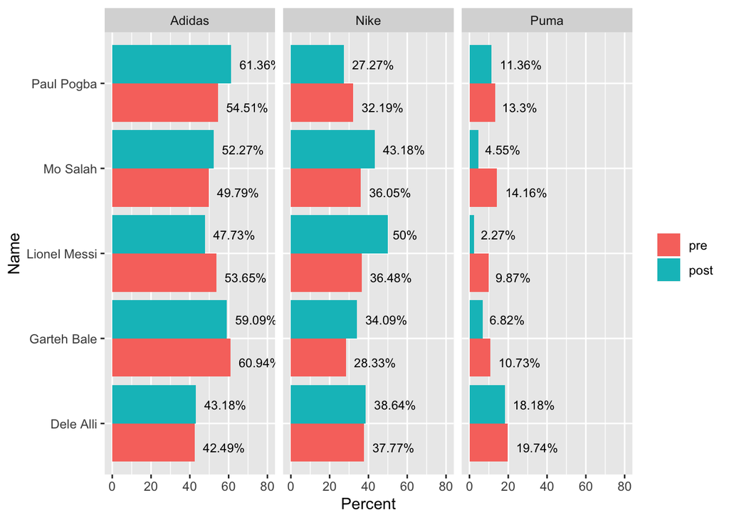

# Brand Perception

## Brand Ownership

Asking our users which brands they were buying and using for football boots, we can see that *adidas* is the Onefootball users go-to shoe brand. The campaign has increased this perception and pushed *adidas* from 62% to 82%.

**Learnings:** Not only is adidas the most popular brand among our users, the campaign managed to let Nike far behind in the *post* measurement.

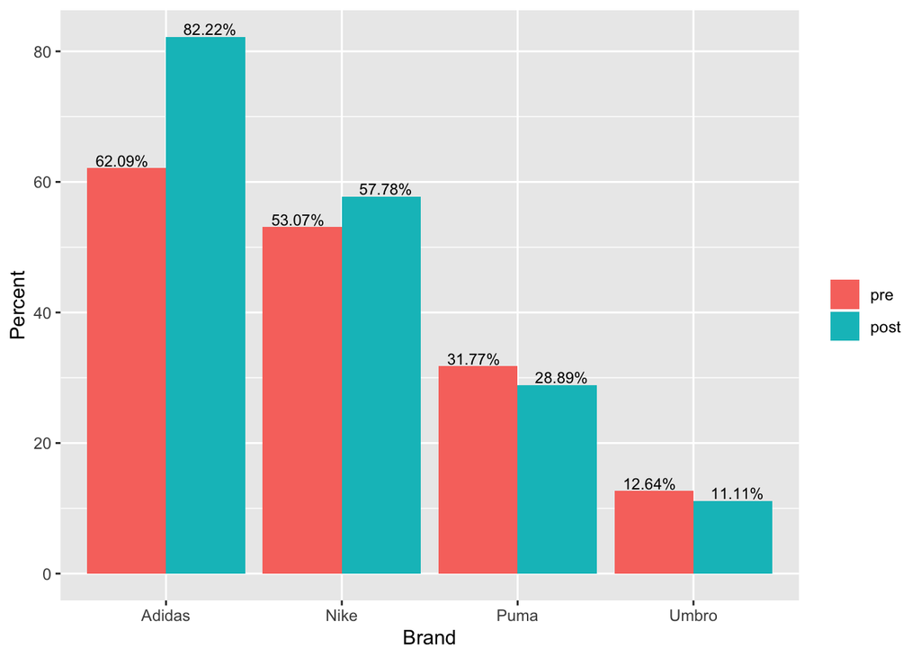

Thes effects are particularly interesting, because more than 40% of the surveyed Onefootball users are either helping others to pick the right shoe or are buying shoes for their children.

## Purchase Intention

We asked our users *How likely are you to consider the following brands when buying the next pair of football boots?* on a scale from 0 (*very unlikely*) to 10 (*very likely*). We can see that before the adidas campaign on Onefootball, both adidas and Nike were the most considered brands for the next purchase. After the campaign, Nike lost a few points, making Adidas the most considered brand for future purchases.

**Learnings:** The consideration score stayed in a strong high for adidas!

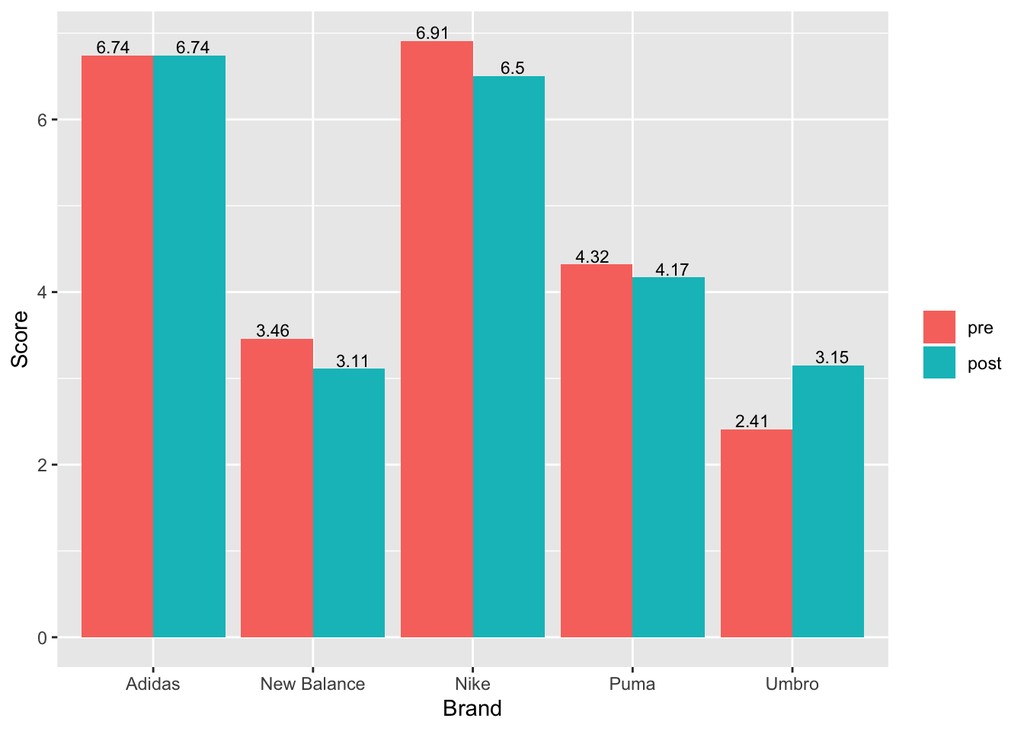

## First-choice Brand

We asked our users which is their top brand when buying football boots. *Pre* campaign we can see that the top brand is slightly in favor to Nike, however *post* campaign we observe a drastic change with an increse of over 14 percantage points, making adidas the favorite brand of Onefootball users.

**Methodology:** There is no *post* data for New Balance, as no participant selected it as first-choice brand. So the brand is excluded from this analysis.

**Learning:** The campaign had a tremendous effect on our users’ perception of adidas. It is now the first-choice brand among our participants.

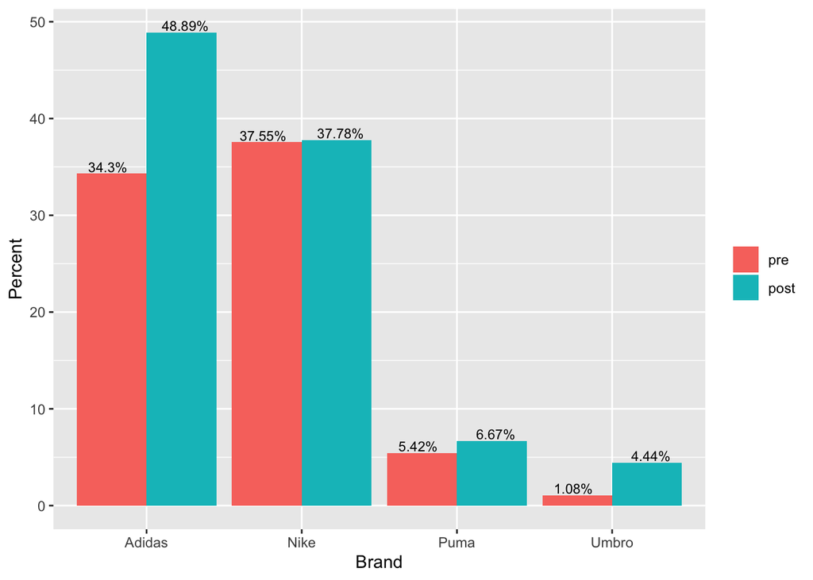

## Brand Recommendation

We asked our participants *How likely would you be to recommend football boots of the following brands to friends and family?* on a scale from 0 (*very unlikely*) to 10 (*very likely*). We can see that *adidas* already scored high before the campaign (7.34), but managed to even increase the average score post campaign (7.65). The biggest competitor Nike lost a few points. Adidas is therefore the most recommended sports brand among Onefootball participants.

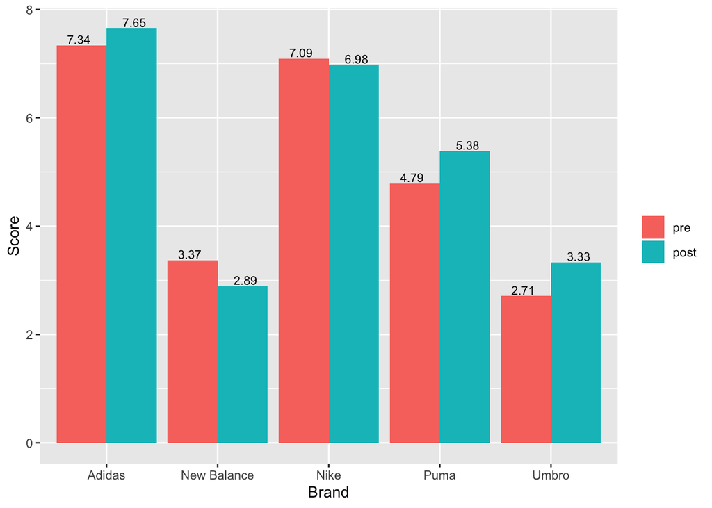

# Learnings and Next Steps

adidas ran a brand campaign on Onefootball. We measured the branding impact as a result of the campaign on our platform. We can see across multiple measures and items that adidas managed to increase their overall great brand perception among our audience and make a higher share of people call adidas their first choice brand. Also, we measure a higher share of participants reporting that they own adidas boots after the campaign has ended. While we can not directly conclude an immediate impact of the campaign, we found this effect to be significant. When it comes to the direct recall of the campaign, we find a boost in ad recall post campaign.

Overall, from a research perspective, we come to the conclusion that this campaign was a great success in terms of Brand Recognition and Brand Image.